# ves() - Vector Exponential Smoothing

Ivan Svetunkov

2019-12-10

This vignette covers `ves()` function, which is a part of smooth package. In this vignette we will use data from `Mcomp` package, so it is advised to install it.

Let’s load the necessary packages:

```r
require(smooth)
require(Mcomp)
```

We will use to time series from the M3 united in a vector:

```r
Y <- cbind(M3$N2570$x,M3$N2571$x);
```

```r
ves(Y, h=18, holdout=TRUE, silent=FALSE)
```

```
## Time elapsed: 0.0416 seconds
## Model estimated: VES(ANN)
##
## Loss function type: likelihood; Loss function value: 13.7174
## Sample size: 98
## Number of estimated parameters: 6
## Number of series: 2
## Number of degrees of freedom per series: 95
## Information criteria:
##      AIC     AICc      BIC     BICc
## 1906.528 1919.702 1914.283 1933.197
```

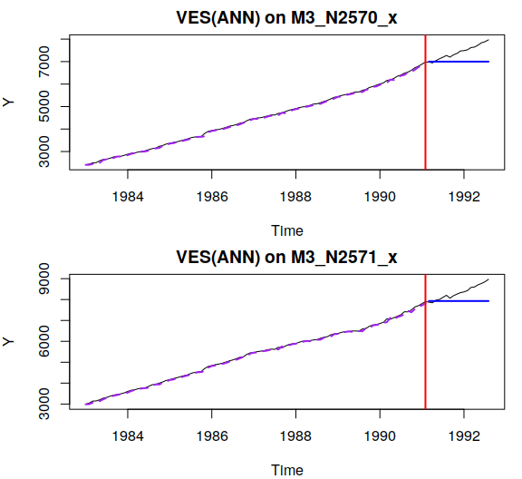

The output tells us how much time the estimation took, what model we estimated, how many parameters were estimated, the cost function type used and its value and finally the information criteria. Currently we do not provide error measures for the holdout, this functionality will be available with newer releases of `smooth`.

In some cases we may decide that the series should be connected with each other. In this case we can ask function to use “dependent” persistence. This means that along with the individual smoothing parameters, we will estimate cross-series ones. Here’s the example:

```r
ourModel <- ves(Y, "AAN", persistence="d", h=18, holdout=TRUE, silent=FALSE)
```

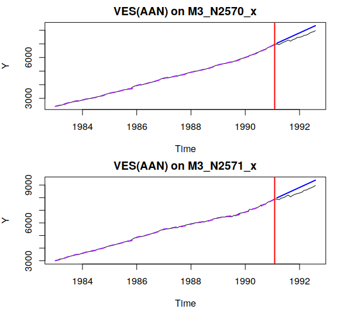

The resulting persistence matrix contains more values than the individual one:

```r
ourModel$persistence
```

```
##                  M3_N2570_x  M3_N2571_x
## M3_N2570_x_level 0.82787787 0.009755761
## M3_N2570_x_trend 0.08923757 0.024368863
## M3_N2571_x_level 0.43944300 0.448034361
## M3_N2571_x_trend 0.03972811 0.098483610
```

Currently we have pure additive and pure multiplicative models only, and I don’t intend introducing mixed models for VES at all, because I think that they are evil. The multiplicative model implemented in VES is in fact just an additive model applied to the data in logarithms. Let’s see how the damped trend multiplicative seasonal model with individual damping and smoothing parameters looks like:

```r
ourModel <- ves(Y, "MMdM", phi="i", persistence="i", h=18, holdout=TRUE)
```

There are different options for the seasonal models. For example, you can set a common seasonal component between the series with the equal weights:

```r
ourModel <- ves(Y, "MMdM", persistence="c", seasonal="c", h=18, holdout=TRUE, silent=F)
```

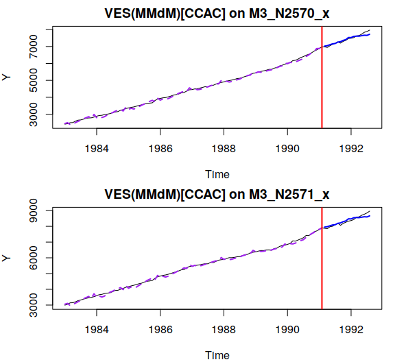

Number of estimated parameters in the model can be extracted via `nparam()` method. However, when it comes to the calculation of the number of degrees of freedom in the model, this value is divided by the number of series (Lütkepohl 2005). So both `ourModel$Sigma` and all the information criteria rely on the $df = T - k_m$, where $T$ is the number of observations and $k_m = \frac{k}{m}$ is the number of parameters $k$ per series ($m$ is the number of series).

AICc and BICc for the vector models are calculated as proposed in (Bedrick and Tsai 1994) and (Tremblay and Wallach 2004).

Currently we don’t do model selection, don’t have exogenous variables and don’t produce conditional prediction interval. But at least it works and allows you to play around with it :).

### References

Bedrick, Edward J, and Chih-Ling Tsai. 1994. “Model Selection for Multivariate Regression in Small Samples.” *Biometrics* 50 (1): 226. https://doi.org/10.2307/2533213.

Lütkepohl, Helmut. 2005. *New Introduction to Multiple Time Series Analysis*. Springer Berlin Heidelberg. https://doi.org/10.1007/978-3-540-27752-1.

Silva, Ashton de, Rob J Hyndman, and Ralph Snyder. 2010. “The vector innovations structural time series framework.” *Statistical Modelling: An International Journal* 10 (4): 353–74. https://doi.org/10.1177/1471082X0901000401.

Tremblay, Marie, and Daniel Wallach. 2004. “Comparison of parameter estimation methods for crop models.” *Agronomie* 24 (6-7): 351–65. https://doi.org/10.1051/agro:2004033.